# Probability & Statistics

## Probability

For now let's stick to the intuitive definition of probability, i.e. what is the chance of an event occuring?

Let's discuss a bit - how would we go about defining this term? Take some examples from lab, without quantifying...

## Statistics

There are many situations where we have to make a decision under uncertainty. How do we decide then?

A general template provided for the "most correct" answer is provided by Statistics:

1. fix a small number as your "allowed" probability of error (what do we mean by this?) and then
2. deduce some threshold based on it

When is this hard to do? When is it easy?

What remains is to be able to calculate the probabilities.

# Probability: Quantifying randomness/uncertainty:

## Or how 'random' is random?

- ### Coin toss
- ### Die
- ### An example from biology

### What do these numbers mean?

Coin toss summary:

If all outcomes are equally likely (no biases). Then,

Probability of 'Heads' turning up = 1/2

Probability of 'Tails' turning up = 1/2

If biased?

```
#Heads = 4917
#Tails = 5083
```

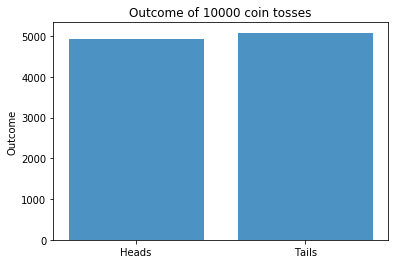

```python
from random import randint
import numpy as np
import matplotlib.pyplot as plt
num = 10000
flips = [randint(0,1) for r in range(num)]
# flips = [np.random.binomial(1,0.1) for r in range(num)]
n_Tails = sum(flips)
n_Heads = num - n_Tails
events = ('Heads', 'Tails')
e_pos = np.arange(len(events))
outcome = [n_Heads, n_Tails]
plt.bar(e_pos, outcome, align='center', alpha=0.8)
plt.xticks(e_pos, events)
plt.ylabel('Outcome')
plt.title('Outcome of %d coin tosses' %num)
print("#Heads =", n_Heads)
print("#Tails =", n_Tails)
plt.show()
```

Playing a die summary:

If all outcomes are equally likely (no biases). Then,

Probability of '1' turning up = 1/6

Probability of '2' turning up = 1/6

Probability of '3' turning up = 1/6

Probability of '4' turning up = 1/6

Probability of '5' turning up = 1/6

Probability of '6' turning up = 1/6

Again, if biased?

Can we make this look like a coin toss?

An example from biology:

If I were to pick one nucleotide from any organism's genes at random, what would it be? (incomplete question? let's refine it and try to answer!)

Probability of picking out an 'Adenine' (or 'A') = 1/4

Probability of picking out an 'Guanine' (or 'G') = 1/4

Probability of picking out an 'Thymine' (or 'T') = 1/4

Probability of picking out an 'Cytosine' (or 'C') = 1/4

And how would you check that? Count them!

Hold on. Are we making some mistakes/implicit assumptions? Are they reasonable?

What if we were not to pick an organism at random but choose specifically yeast (*Saccharomyces cerevisiae*)?

Of course, we would then be much mistaken in our assignment of probabilities.

In yeast,

Probability of picking out an 'Adenine' (or 'A') = 31/100

Probability of picking out an 'Guanine' (or 'G') = 19/100

Probability of picking out an 'Thymine' (or 'T') = 31/100

Probability of picking out an 'Cytosine' (or 'C') = 19/100

Is there a reason that probability of 'G' is equal to that of 'C'?

## Conditionality, Dependence and Independence

[figure not shown]

Questions we could ask:

- If I picked 'A', what is the chance that of 'T' on the other strand at the same position?
- If I picked 'A', what is the chance that of 'T' on the same strand at an adjacent position?

Let's discuss more examples...

## Discrete and Continuous

So far what is on these slides has been discrete variables. What about probability of continuous variables?

[figure not shown]

Define chances for a good player, a bad player, a drunk bad player?

[figure not shown]

Probability of dart in a region = Area of the region / Total area

## Notations and why do we use them?

Disclaimer: No ulterior motives of bringing you to the dark side (mathematics) intended.

### The two notions of probability

It so happens that the best way we have so far is to turn to models in probability and apply them.

The two ways in which we understand probability:

1. Classical sense - chance of occurrence over multiple (infinite) repetitions. This is the way we usually choose and will be using for the major part of this workshop
2. Bayesian sense - a reasonable expectation given our knowledge

### A little bit of formaility

This section is purely for the purposes of agreeing on a common language so that we can deal with the later, more interesting sections. Also, it is in hopes to help you get back to these slides or any other text on Probability and Statistics in future.

We will take some toy examples and try to work out the probabilities of events. But first, ground rules:

1. We will keep in mind what all events could occur. Let's put all of these in one box and call it $\Omega$
2. Out of all these events we shall denote probability of a particular event E as P(E) (read P of E). This P(E) is a positive real number less than one.

$$0 \leq P(E) \leq 1$$

In case of continuous variables we prefer to define probability densities:

- $p(x) = P(x<E<x+dx)$ and
- $ \int p(x) dx = 1$

Too abstract? Hold on... let's revisit some of our previous examples:

## Revisiting our examples

### Coin toss

Let's say we toss a coin once. All that can happen is - it will land with Head facing up or Tails. Let's put these possible events in a box/set $\Omega = \{H,T\}$.

Now we need to assign numbers to these events, i.e. deduce/decide what their probabilities. Considering the coin is fair, we could say P(H) = P(T) = 0.5. In other words, both outcomes are equally likely...so 50-50 chance for both.

What if we do the same with a die?

You know P('1') = P('2') = P('3') = P('4') = P('5') = P('6') = 1/6.

How would we check if our asignment of probabilities is correct? Well, we would take the coin and toss it multiple times, say a 100 times and see how many times Head or Tail turn up. So we would expect close to 50 times (heads or tails). This is intricately related to the Classical notion of probability - that over multiple realizations the proportion of times the event E happens is its probability, i.e

\begin{equation} P(E) = \frac{\text{no. of times event E happened}}{\text{Total no. of realizations}} \end{equation}

And the same goes for cards!

In some sense, they are all "coin tosses" in which all outcomes are equally likely.

Now, what's a simple "coin toss" example in biology?

If I were to pick one nucleotide from any organism's genes at random, what would it be? It could be any one from $\Omega = \{A,T,G,C\}$ with probability

P(A) = P(T) = P(G) = P(C) = 0.25

And how would you check that? Count them!

What if we were not to pick an organism at random but choose a specifically yeast (Saccharomyces cerevisiae)? We would then be much mistaken in our assignment of probabilities. In fact, we would something more close to

P(A) = P(T) = 0.31

P(G) = P(C) = 0.19

This is case of a biased 4-sided "coin" or "die".

## Revisiting our examples

### Coin toss

Let's put these possible events in a box/set $\Omega = \{H,T\}$.

P(H) = P(T) = 0.5

This defines our 'Probability Space'!

For a biased coin, $\Omega = \{H,T\}$

P(H) = p

P(T) = 1-p

## Revisiting our examples

### Picking a nucleotide

$Ω={A,T,G,C}$

P(A) = P(T) = P(G) = P(C) = 0.25

For yeast, $Ω={A,T,G,C}$

P(G) = P(C) = p

P(T) = P(A) = $\frac{1-2p}{2}$

## Dependence

If 'A' is picked, what is the probability of 'T' on complementary strand?

$ P(T|A) = \frac{P(A\cap T)}{P(A)} $

Is this formulation correct? Need to make it precise: what's the sample space $\Omega$?

References:

- Probability and Statistics. Manjunath Krishnapur, Dept. of Mathematics, IISc